# Refresher assignment module 1

2022-09-05

## Module 1 R Refresher Assignment

Tom Rozanov

**Libraries we will need**

```r
library(tidyverse) #tidyverse package
```

```r
library(esquisse) #esquisse package to help with ggplot
```

**Importing diamond data as a tibble**

```r
diamonddata = as_tibble(diamonds)
```

**Question 1: How many rows are in the dataset?**

```r
str(diamonddata) # using Structure to answer Q's 1 & 2
```

```
## tibble [53,940 × 10] (S3: tbl_df/tbl/data.frame)
##  $ carat  : num [1:53940] 0.23 0.21 0.23 0.29 0.31 0.24 0.24 0.26 0.22 0.23 ...
##  $ cut    : Ord.factor w/ 5 levels "Fair"<"Good"<..: 5 4 2 4 2 3 3 3 1 3 ...
##  $ color  : Ord.factor w/ 7 levels "D"<"E"<"F"<"G"<..: 2 2 2 6 7 7 6 5 2 5 ...
##  $ clarity: Ord.factor w/ 8 levels "I1"<"SI2"<"SI1"<..: 2 3 5 4 2 6 7 3 4 5 ...
##  $ depth  : num [1:53940] 61.5 59.8 56.9 62.4 63.3 62.8 62.3 61.9 65.1 59.4 ...
##  $ table  : num [1:53940] 55 61 65 58 58 57 57 55 61 61 ...
##  $ price  : int [1:53940] 326 326 327 334 335 336 336 337 337 338 ...
##  $ x      : num [1:53940] 3.95 3.89 4.05 4.2 4.34 3.94 3.95 4.07 3.87 4 ...
##  $ y      : num [1:53940] 3.98 3.84 4.07 4.23 4.35 3.96 3.98 4.11 3.78 4.05 ...
##  $ z      : num [1:53940] 2.43 2.31 2.31 2.63 2.75 2.48 2.47 2.53 2.49 2.39 ...
```

Answer is 53,940

**Question 2: How many columns are in the dataset?**

Answer is 10 from above.

**Question 3: Using ggplot, create a scatterplot of caret (x axis) versus price (y axis). Which statement best describes the relationship between “caret” and “price”?**

```r
#esquisser() # Using Esquisse to examine relationship and output ggplot code
```

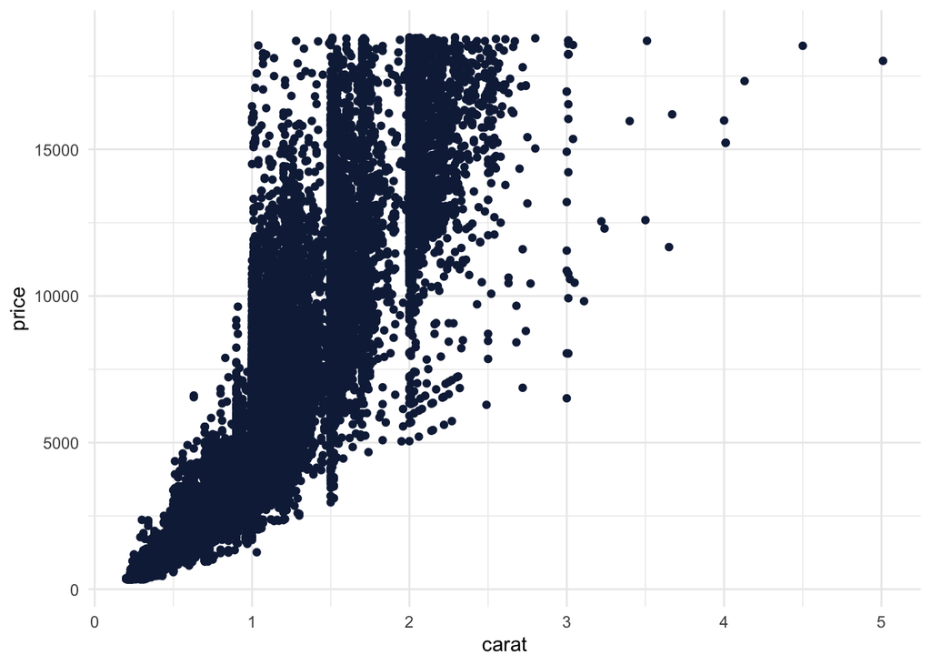

```r
ggplot(diamonddata) +
  aes(x = carat, y = price) +
  geom_point(shape = "circle", size = 1.5, colour = "#112446") +
  theme_minimal()
```

Answer: B. As caret increases price increases

**Question 4: Repeat Question 3, but in this plot color the scatterplot points by the “cut” variable. Which statement best describes the relationship between “cut” and “price”?**

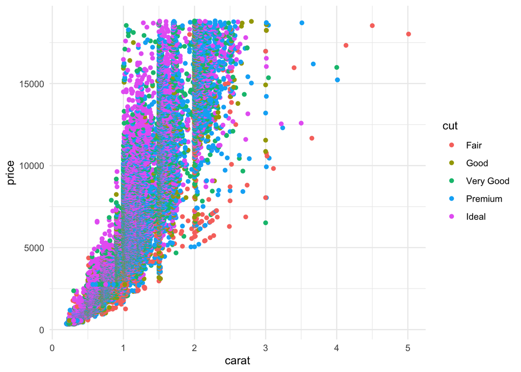

```r
ggplot(diamonddata) +
  aes(x = carat, y = price, colour = cut) +
  geom_point(shape = "circle", size = 1.5) +
  scale_color_hue(direction = 1) +
  theme_minimal()
```

Answer: A. As cut quality increases price increases

Question 5: Repeat Question 4, but in this plot you should facet by “color”. Faceting a plot is described at  
this link: http://www.cookbook-r.com/Graphs/Facets_(ggplot2)/.

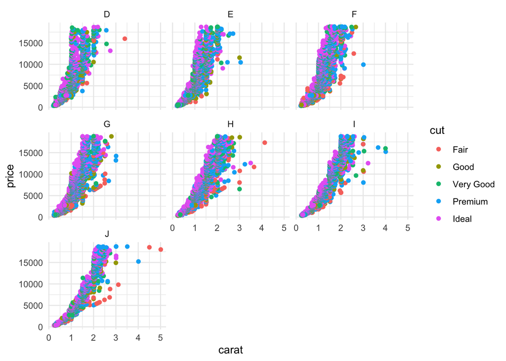

```r
ggplot(diamonddata) +
  aes(x = carat, y = price, colour = cut) +
  geom_point(shape = "circle", size = 1.5) +
  scale_color_hue(direction = 1) +
  theme_minimal() +
  facet_wrap(vars(color))
```

Answer: C. Creates a separate scatterplot for each “color”

**Question 6: Use the “read_csv” function to read-in the “InventoryData.csv” file as a data frame called “inventory”. NOTE: In this course we will ALWAYS (unless instructed otherwise) use the “read_csv” command. Do NOT use the “read.csv” command.**

```r
inventory = read_csv(file = "InventoryData.csv") #Reading a file stored in the same directory and creating an object/tibble
str(inventory)
```

```
## spec_tbl_df [13,561 × 6] (S3: spec_tbl_df/tbl_df/tbl/data.frame)
##  $ Item SKU         : chr [1:13561] "0100" "0100" "0100" "0100" ...
##  $ Store            : chr [1:13561] "003480" "01611" "01611" "020109" ...
##  $ Supplier         : chr [1:13561] "A" "B" "D" "B" ...
##  $ Cost per Unit ($): num [1:13561] 125.32 115.12 53.61 2.26 60.51 ...
##  $ On Hand          : num [1:13561] 159 40 174 176 74 48 6 129 82 17 ...
##  $ Annual Demand    : num [1:13561] 1693 351 1691 1559 733 ...
##  - attr(*, "spec")=
##   .. cols(
##   ..   `Item SKU` = col_character(),
##   ..   Store = col_character(),
##   ..   Supplier = col_character(),
##   ..   `Cost per Unit ($)` = col_double(),
##   ..   `On Hand` = col_double(),
##   ..   `Annual Demand` = col_double()
##   .. )
##  - attr(*, "problems")=<externalptr>
```

**In the “inventory” data frame that you have just created, what type of variable is “Supplier”?**

Answer: D. Character

**Question 7 In the “inventory” data frame that you have just created, what is the mean of the “On Hand” variable?**

```r
summary(inventory) #Finding mean using Summary function
```

```
##    Item SKU            Store             Supplier         Cost per Unit ($)
##  Length:13561       Length:13561       Length:13561       Min.   :   0.0
##  Class :character   Class :character   Class :character   1st Qu.: 137.0
##  Mode  :character   Mode  :character   Mode  :character   Median : 377.5
##                                                           Mean   : 504.4
##                                                           3rd Qu.: 775.5
##                                                           Max.   :1982.3
##     On Hand      Annual Demand
##  Min.   :  0.0   Min.   :   0.0
##  1st Qu.: 50.0   1st Qu.: 483.0
##  Median :101.0   Median : 965.0
##  Mean   :100.5   Mean   : 966.2
##  3rd Qu.:151.0   3rd Qu.:1448.0
##  Max.   :200.0   Max.   :2150.0
```

```r
mean(inventory$`On Hand`) #Finding mean using Mean function (more precise)
```

```
## [1] 100.5373
```

Mean for “On Hand” variable is 100.5373 or 100.54 rounded to 2 d.p.

**Question 8: Use a filter to create a new data frame called “inventoryA” containing only inventory from Supplier A. How many rows are in this new data frame?**

```r
inventoryA = inventory %>% filter(Supplier == "A") #Creates data frame for Inventory that has Supplier "A"

nrow(inventoryA)
```

```
## [1] 3695
```

Answer: There are 3695 rows in “InventoryA”

Question 9: What does the line of code shown below do? Note the use of the backtick character (on the  
tilde key on your computer’s keyboard) to delineate the variable names with spaces in them.

```r
inventoryA = mutate(inventoryA, OnHandRatio = `On Hand`/ `Annual Demand`)
```

Answer: B. Creates a new variable called “OnHandRatio”

**Question 10: Using the “inventoryA” object that you created in Question 9, create a new data frame called “avg_cost” that contains the average “Cost per Unit ($)” by each “Item SKU” (let this quantity be in a variable called “SKUAvgCost.**

**Hint: Recall the summarize and group_by functions and the use of the backtick character from Task 8. Your data frame should have only two columns:“Item SKU” and “SKUAvgCost”.**

**What is the “SKUAvgCost” of items with an “Item SKU” of 011?**

```r
avg_cost = inventoryA %>% group_by(`Item SKU`) %>% summarise(SKUAvgCost = mean(`Cost per Unit ($)`))
```

**What is the “SKUAvgCost” of items with an “Item SKU” of 011?**

12.33000